# 市场问卷调研数据定量分析标准化流程

数据分析/数据挖掘/数据可视化

LiXin Wu

2019年5月12号

## 研究背景

商业活动中的市场调研可以帮助我们很好的了解市场趋势,产品需求,消费者偏好等等,从而帮助决策者做出正确的商业决策.虽然问卷调研已经发展了很长时间,但标准化的数据格式处理,数据挖掘与可视化,规范式的方法论还没有很好的在中国传播,相比国外的社会科学家设计除了很好处理问卷调研数据的程序包,通过软件程序让定量分析与结果呈现更加一目了然. 本文主要是借鉴与学习德国汉堡埃彭多夫大学Daniel strengejacke这位教授关于市场调研的研究成果. 探索性,描述性,因果性,预测.

## 问卷设计

Data frame: efc

| ID | Name | Label | Values | Value Labels |
| --- | --- | --- | --- | --- |
| 1 | c12hour | average number of hours of care per week | *range: 4-168* |  |
| 2 | e15relat | relationship to elder | 1 2 3 4 5 6 7 8 | spouse/partner child sibling daughter or son -in-law ancle/aunt nephew/niece cousin other, specify |
| 3 | e16sex | elder’s gender | 1 2 | male female |
| 4 | e17age | elder’ age | *range: 65-103* |  |
| 5 | e42dep | elder’s dependency | 1 2 3 4 | independent slightly dependent moderately dependent severely dependent |
| 6 | c82cop1 | do you feel you cope well as caregiver? | 1 2 3 4 | never sometimes often always |
| 7 | c83cop2 | do you find caregiving too demanding? | 1 2 3 4 | Never Sometimes Often Always |
| 8 | c84cop3 | does caregiving cause difficulties in your relationship with your friends? | 1 2 3 4 | Never Sometimes Often Always |
| 9 | c85cop4 | does caregiving have negative effect on your physical health? | 1 2 3 4 | Never Sometimes Often Always |
| 10 | c86cop5 | does caregiving cause difficulties in your relationship with your family? | 1 2 3 4 | Never Sometimes Often Always |
| 11 | c87cop6 | does caregiving cause financial difficulties? | 1 2 3 4 | Never Sometimes Often Always |
| 12 | c88cop7 | do you feel trapped in your role as caregiver? | 1 2 3 4 | Never Sometimes Often Always |
| 13 | c89cop8 | do you feel supported by friends/neighbours? | 1 2 3 4 | never sometimes often always |
| 14 | c90cop9 | do you feel caregiving worthwhile? | 1 2 3 4 | never sometimes often always |
| 15 | c160age | carer’ age | *range: 18-89* |  |
| 16 | c161sex | carer’s gender | 1 2 | Male Female |
| 17 | c172code | carer’s level of education | 1 2 3 | low level of education intermediate level of education high level of education |
| 18 | c175empl | are you currently employed? | 0 1 | no yes |
| 19 | barthtot | Total score BARTHEL INDEX | *range: 0-100* |  |
| 20 | neg_c_7 | Negative impact with 7 items | *range: 7-28* |  |
| 21 | pos_v_4 | Positive value with 4 items | *range: 5-16* |  |
| 22 | quol_5 | Quality of life 5 items | *range: 0-25* |  |
| 23 | resttotn | Job restrictions | *range: 0-4* |  |
| 24 | tot_sc_e | Services for elderly | *range: 0-9* |  |
| 25 | n4pstu | Care level | 0 1 2 3 4 | No Care Level Care Level 1 Care Level 2 Care Level 3 Care Level 3+ |
| 26 | nur_pst | Care level | 1 2 3 | Care Level 1 Care Level 2 Care Level 3/3+ |
| 27 | grp | relationship to elder |  | spouse/partner child sibling daughter or son -in-law ancle/aunt nephew/niece cousin other, specify |
| 28 | negc7d | Negative impact with 7 items |  | 0 1 |

## 问卷数据

数据预览

| Row | c12hour | e15relat | e16sex | e17age | e42dep | c82cop1 | c83cop2 | c84cop3 | c85cop4 | c86cop5 | c87cop6 | c88cop7 | c89cop8 | c90cop9 | c160age | c161sex | c172code | c175empl | barthtot | neg_c_7 | pos_v_4 | quol_5 | resttotn | tot_sc_e | n4pstu | nur_pst | grp | negc7d |
| --- | --- | --- | --- | --- | --- | --- | --- | --- | --- | --- | --- | --- | --- | --- | --- | --- | --- | --- | --- | --- | --- | --- | --- | --- | --- | --- | --- | --- |
| 3 | 70 | 1 | 2 | 82 | 3 | 2 | 2 | 1 | 4 | 1 | 1 | 1 | 4 | 3 | 80 | 1 | 1 | 0 | 35 | 11 | 13 | 7 | 0 | 1 | 2 | 2 | spouse/partner | 0 |
| 4 | 168 | 1 | 2 | 67 | 4 | 4 | 1 | 3 | 1 | 1 | 1 | 1 | 2 | 4 | 69 | 1 | 2 | 0 | 0 | 10 | 15 | 12 | 2 | 0 | 3 | 3 | spouse/partner | 0 |
| 1 | 16 | 2 | 2 | 83 | 3 | 3 | 2 | 2 | 2 | 1 | 1 | 2 | 3 | 3 | 56 | 2 | 2 | 1 | 75 | 12 | 12 | 14 | 0 | 4 | 0 | NA | child | 1 |
| 2 | 148 | 2 | 2 | 88 | 3 | 3 | 3 | 3 | 3 | 4 | 1 | 3 | 2 | 2 | 54 | 2 | 2 | 1 | 75 | 20 | 11 | 10 | 4 | 0 | 0 | NA | child | 1 |
| 5 | 168 | 2 | 2 | 84 | 4 | 3 | 2 | 1 | 2 | 2 | 2 | 1 | 4 | 4 | 47 | 2 | 2 | 0 | 25 | 12 | 15 | 19 | 2 | 1 | 2 | 2 | child | 1 |

数据描述

Component 1

| Row | Missings | Mean | SD | Skew | Item Difficulty | Item Discrimination | α if deleted |  |
| --- | --- | --- | --- | --- | --- | --- | --- | --- |
| do you find caregiving too demanding? | 0.66 % | 2.02 | 0.72 | 0.65 | 0.51 | 0.549 | 0.75 |  |
| does caregiving cause difficulties in your relationship with your friends? | 0.66 % | 1.63 | 0.87 | 1.3 | 0.41 | 0.562 | 0.746 |  |
| does caregiving have negative effect on your physical health? | 1.10 % | 1.77 | 0.87 | 1.05 | 0.44 | 0.576 | 0.742 |  |
| does caregiving cause difficulties in your relationship with your family? | 0.66 % | 1.39 | 0.67 | 1.76 | 0.35 | 0.449 | 0.772 |  |
| does caregiving cause financial difficulties? | 0.88 % | 1.29 | 0.64 | 2.42 | 0.32 | 0.468 | 0.768 |  |
| do you feel trapped in your role as caregiver? | 0.88 % | 1.92 | 0.91 | 0.82 | 0.48 | 0.617 | 0.731 |  |
| Mean inter-item-correlation=0.378 · Cronbach’s α=0.785 |  |  |  |  |  |  |  |  |

Component 2

| Row | Missings | Mean | SD | Skew | Item Difficulty | Item Discrimination | α if deleted |  |
| --- | --- | --- | --- | --- | --- | --- | --- | --- |
| do you feel you cope well as caregiver? | 0.77 % | 3.12 | 0.58 | -0.12 | 0.78 | 0.258 | 0.414 |  |
| do you feel supported by friends/neighbours? | 0.77 % | 2.16 | 1.04 | 0.32 | 0.54 | 0.255 | 0.415 |  |
| do you feel caregiving worthwhile? | 2.20 % | 2.93 | 0.96 | -0.45 | 0.73 | 0.355 | 0.188 |  |
| Mean inter-item-correlation=0.226 · Cronbach’s α=0.449 |  |  |  |  |  |  |  |  |

|  | Component 1 | Component 2 |
| --- | --- | --- |
| Component 1 | α=0.785 |  |
| Component 2 | -0.318 (<.001) | α=0.449 |
| Computed correlation used pearson-method with listwise-deletion. |  |  |

```
 这作者更加递进了一个层次是直接把问题按照主成分分类.这样对于缺失数据,方差,偏度,均值等有一个很清楚的了解.
```

## 描述性分析

### likert-plot李克特图

```
首先科普利克特量表,可能非marketing专业的童鞋是不了解李克特量表的.利克特量表,是一种现代调查研究中被普遍采用的态度测量表,它的基本形式是给出一组陈述,这些陈述都与某人对某个单独事物的态度有关.要求调查对象表明他是“强烈赞同”、“赞同”、“反对”、“强烈反对”或“未决定”.又称为求和量表.利克特是支持关系理论的创始人,密歇根大学,哥伦比亚大学博士.他的博士论文《态度测量方法》这篇论文成为李克特量表的基础,李克特量表是社会科学家们的一种标准工具.
```

量表可视化

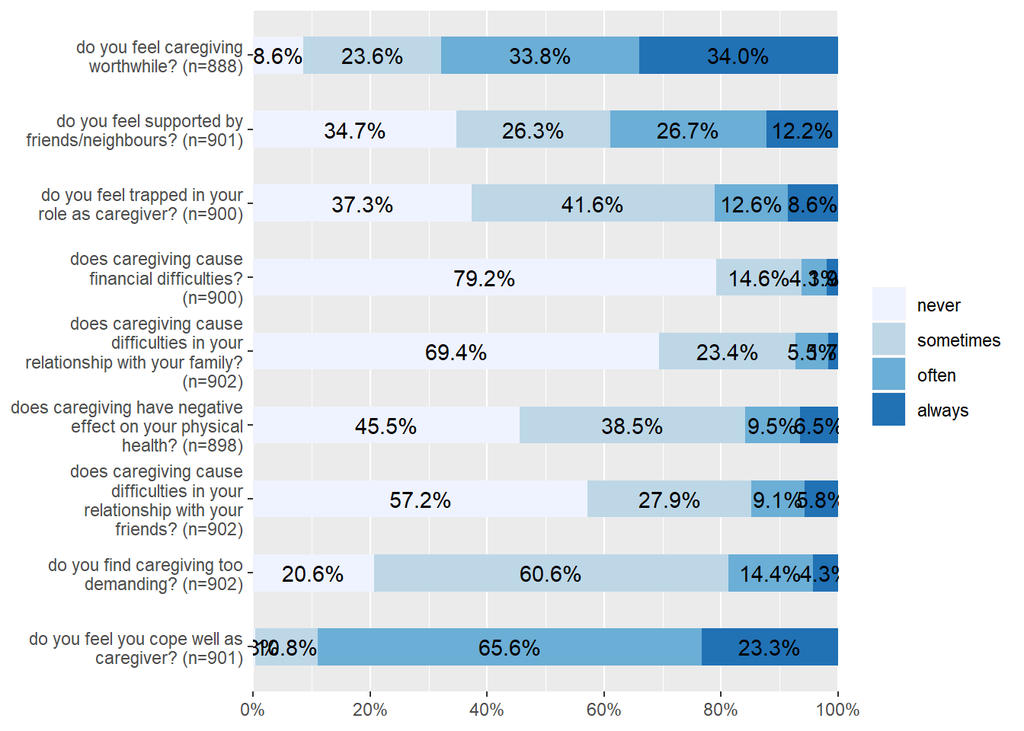

量表分析,求和.

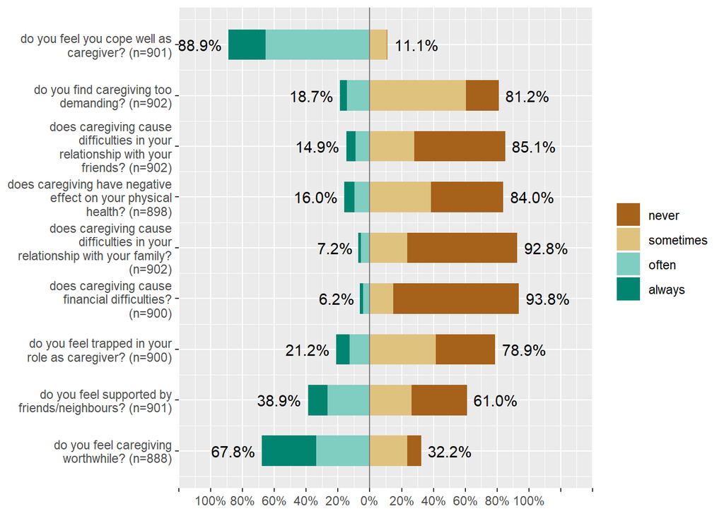

###Likert plot 升级版 主成分分析结合李克特量表

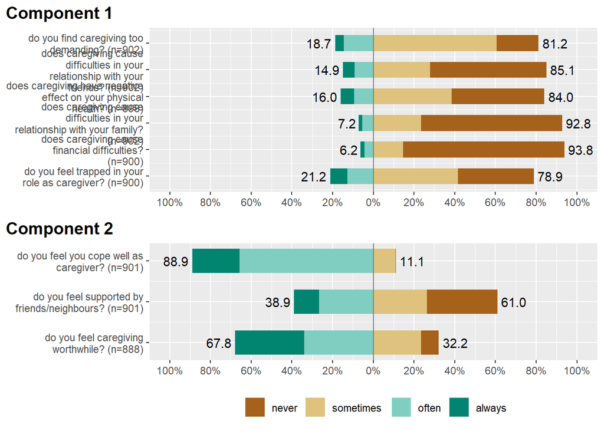

### 性别VS other

```
性别,年龄,教育程度对于社会统计学来说对于个人行为,价值观,消费观会形成比较深的影响,所以也是分析的切入口.这个地方那位作者在数据可视化上做了很大的集成.
```

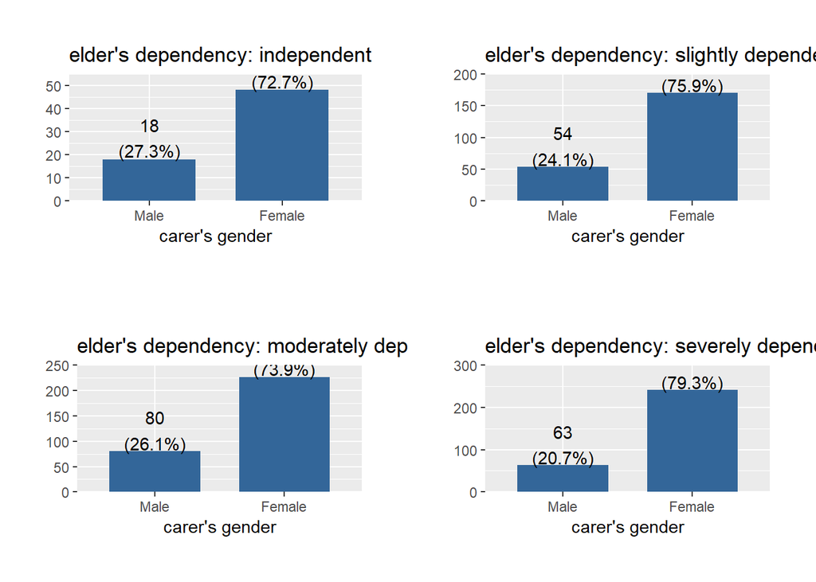

### 年龄VS other

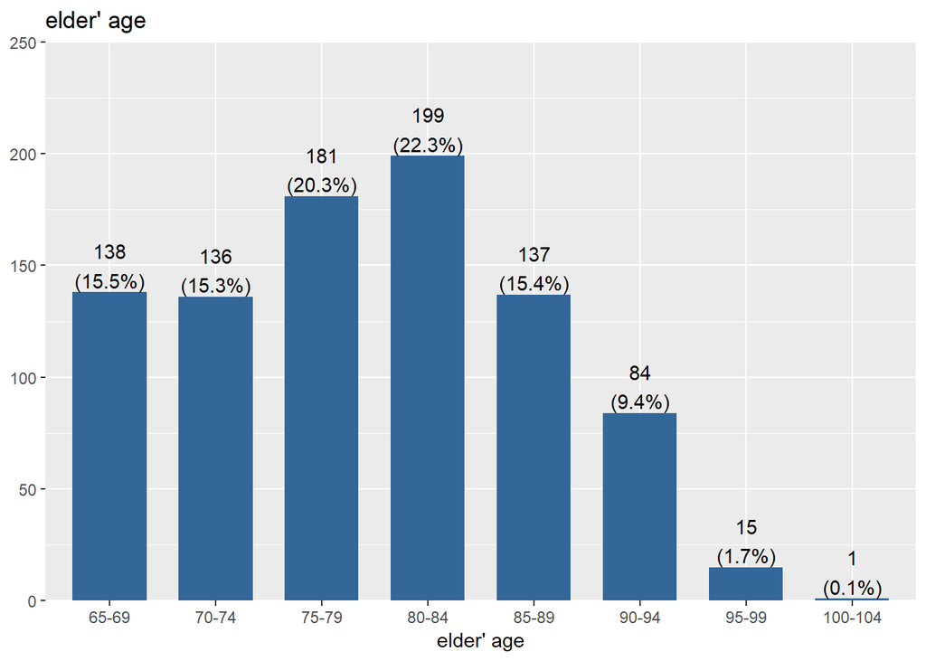

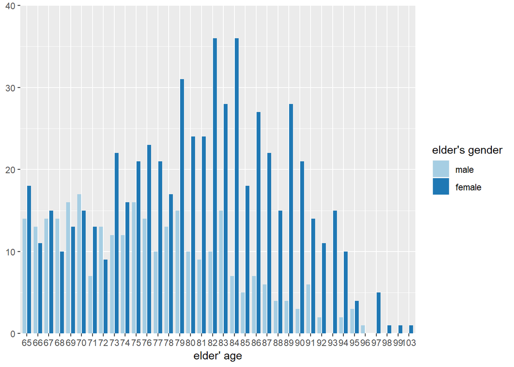

### 教育VS other

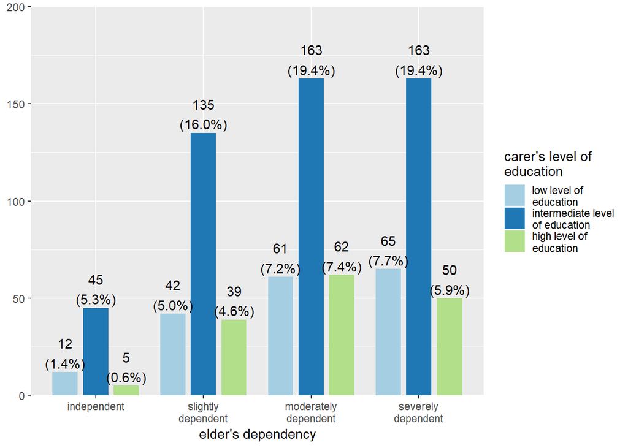

## 探索性分析

探索主要探索的潜在因子变量,以及不同问题的摄入度.通过聚类分析,因子分析(探索性因子,验证性因子,结构性因子),主成分分析,ANOVA分析.见过很多投资策略都是说因子分析,但殊不知因子分析最大的难度是原始数据的统计原则,像大事件,热点概念,板块轮动等等因子,这些数据只能手动录入衡量.

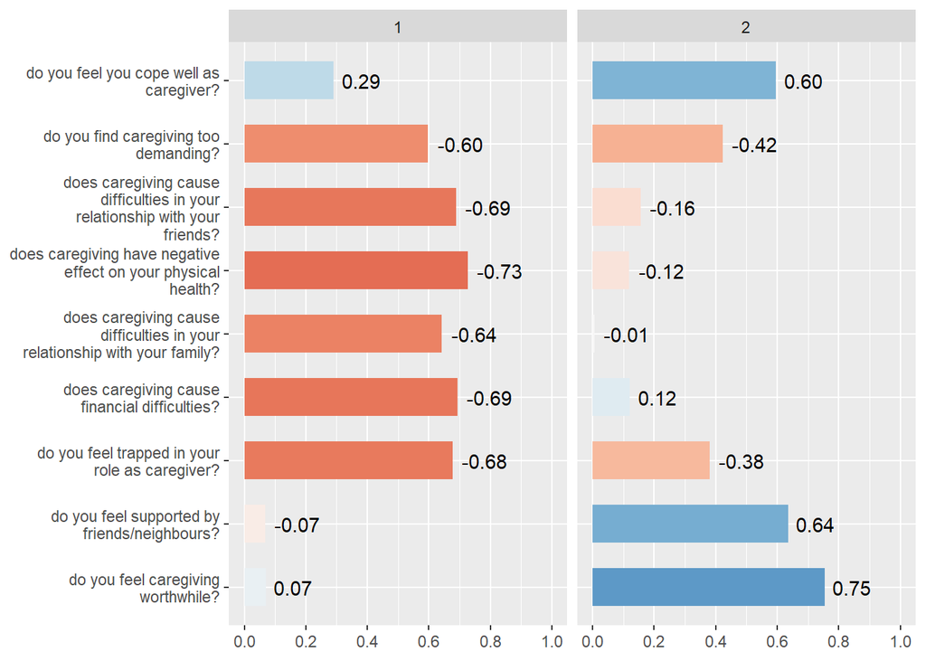

## 预测性分析

```
建立模型,评估与可视化每个变量对于因变量的影响.
```

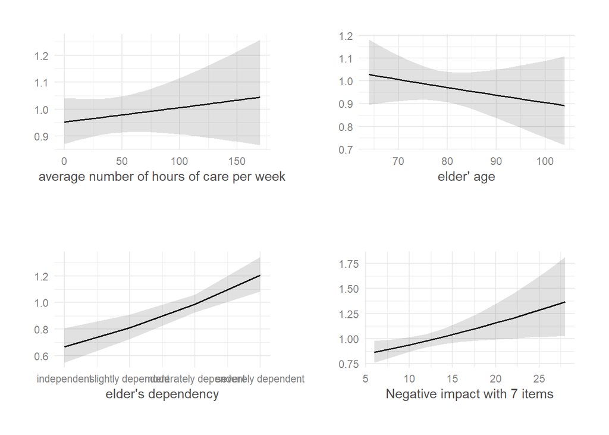

```
模型参数的可视化
```

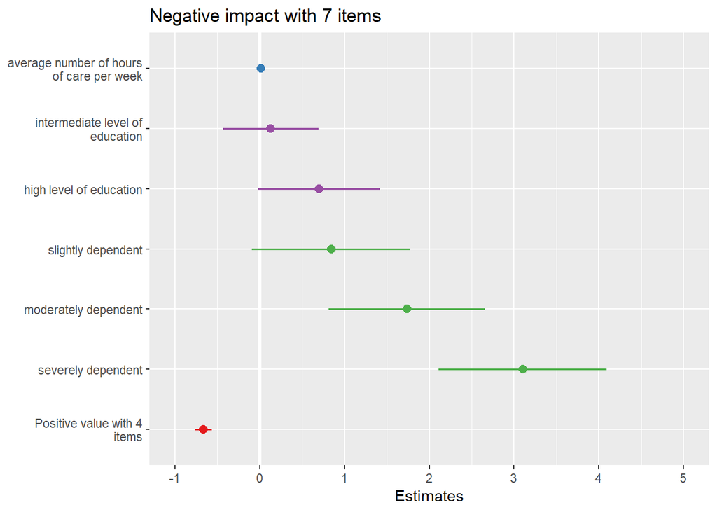

```
模型的评估,共线性,从正态分布.
```

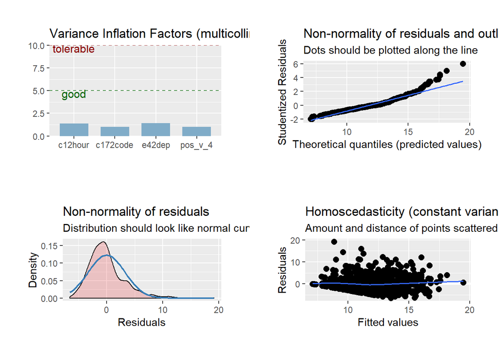

```
响应变量与预测变量之间的关系
```

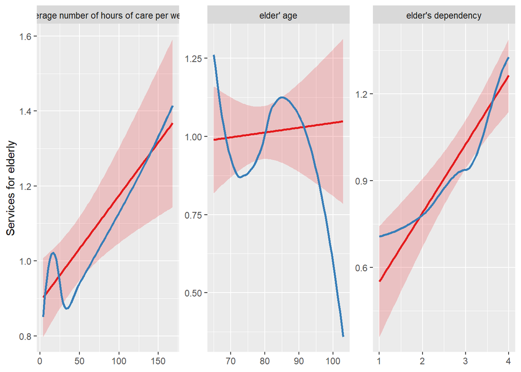

```
这个项目的作者,将问卷调研数据的描述性分析,数据可视化,探索性分析,预测性分析进行了流程的标准化.小编做了一个演示.对于之后问卷的设计,数据类型的设计有了更加清楚的了解.
```